# Covid-19 - Modelagem Causal

Parte I: Aprendizado Bayesiano de estrutura Causal na Síndrome Respiratória Aguda Grave - SRAG

José Elvano Moraes

4/13/2021

$$SRAG^{causal\: modeling} \; \& \; COVID-19_{simulations}$$

*Dataset* = https://dados.gov.br/dataset/bd-srag-2021

*Banco de Dados de Síndrome Respiratória Aguda Grave* - **incluindo dados da COVID-19**

Vigilância de Síndrome Respiratória Aguda Grave (SRAG) O Ministério da Saúde (MS), por meio da Secretaria de Vigilância em Saúde (SVS), desenvolve a vigilância da Síndrome Respiratória Aguda Grave (SRAG) no Brasil, desde a pandemia de Influenza A(H1N1)pdm09 em 2009. A partir disso, esta vigilância foi implantada na rede de Influenza e outros vírus respiratórios, que anteriormente atuava apenas com a vigilância sentinela de Síndrome Gripal (SG).

Recentemente (2020), a vigilância da COVID-19, a infecção humana causada pelo novo Coronavírus, foi incorporada na rede de vigilância da Influenza e outros vírus respiratórios.

Esta página tem como finalidade disponibilizar o legado dos bancos de dados (BD) epidemiológicos de SRAG, da rede de vigilância da Influenza e outros vírus respiratórios, desde o início da sua implantação (2009) até os dias atuais (2021), com a incorporação da vigilância da COVID-19. Atualmente, o sistema oficial para o registro dos casos e óbitos de SRAG é o Sistema de Informação da Vigilância Epidemiológica da Gripe (SIVEP-Gripe).

No Guia de Vigilância Epidemiológica Emergência de Saúde Pública de Importância Nacional pela Doença pelo Coronavírus 2019 estão disponíveis informações sobre definições de casos, critérios de confirmação e encerramento dos casos, dentre outros.

Ressaltamos que os dados da vigilância de SRAG no Brasil disponibilizados nesta página, estão sujeitos a alterações decorrentes da investigação pelas equipes de vigilância epidemiológica que desenvolvem o serviço nas três esferas de gestão.

As bases de dados de SRAG disponibilizadas neste portal passam por tratamento que envolve a anonimização, em cumprimento a legislação.

Os dados de 2021 são disponibilizados semanalmente, às quartas-feiras, podendo, excepcionalmente, a atualização ocorrer em outro dia

Para mais informações, acessar:

Gripe/Influenza - https://saude.gov.br/saude-de-a-z/gripe

COVID-19 - https://coronavirus.saude.gov.br/

Guia Nacional de Vigilância da COVID-19 - https://portalarquivos.saude.gov.br/images/af_gvs_coronavirus_6ago20_ajustes-finais-2.pdf

# Nota

Este documento é ainda tão somente experimentação e análise exploratória em fase absolutamente incipiente. Por isso a falta de estrutura, gráficos não explicativos, *typos*, etc

# Inferência da estrutura da Rede Causal usando o Algoritmo **mmhc**

```
## Rows: 478,866
## Columns: 19
## $ X1         <dbl> 1, 2, 3, 4, 5, 6, 7, 8, 9, 10, 11, 12, 13, 14, 15, 16, 17, …
## $ FEBRE      <fct> 2, 1, 1, 1, 2, 2, 2, 1, 2, 2, 1, 1, 1, NA, 1, 9, 1, 1, NA, …
## $ TOSSE      <fct> 1, 1, 1, 1, 2, 1, 1, 1, 2, 2, 2, 2, NA, 1, 1, 9, 1, 1, 1, 2…
## $ GARGANTA   <fct> 2, 2, 2, 2, 2, 1, 2, 1, 2, 2, 2, 2, NA, NA, NA, 9, NA, 2, 1…
## $ DISPNEIA   <fct> 1, 1, 2, 2, 1, 2, 1, 1, 1, 2, 2, 2, NA, NA, 1, 9, NA, 2, NA…
## $ DESC_RESP  <fct> 1, 1, 1, 1, 1, 2, 1, 1, 1, 2, 2, 2, NA, 1, 1, 1, NA, 2, NA,…
## $ SATURACAO  <fct> 1, 2, 2, 1, 1, 2, 1, 1, 1, 2, 2, 2, NA, 1, 1, 9, NA, 2, NA,…
## $ DIARREIA   <fct> 2, 2, 2, 2, 2, 2, 2, 2, 2, 2, 1, 1, 1, 1, NA, 9, NA, 2, NA,…
## $ VOMITO     <fct> 2, 2, 2, 2, 2, 2, 2, 2, 2, 2, 2, 1, NA, NA, NA, 9, NA, 1, N…
## $ OUTRO_SIN  <fct> 2, 2, 2, 1, NA, 2, 2, 1, 2, NA, 2, 2, 1, NA, NA, 9, NA, 2, …
## $ HOSPITAL   <fct> 1, 1, 1, 1, 1, 2, 1, 1, 1, 1, 2, 1, 1, 1, 1, 1, 1, 1, 2, 1,…
## $ EVOLUCAO   <fct> NA, 1, 1, 1, NA, 1, 1, 1, 2, 1, NA, 1, 1, 1, 2, 9, NA, NA, …
## $ RENAL      <fct> 2, 1, NA, 2, NA, NA, 2, 2, 2, NA, 2, NA, 1, NA, NA, NA, NA,…
## $ DIABETES   <fct> 2, 1, NA, 1, NA, NA, 1, 2, 2, NA, 2, NA, 1, NA, NA, NA, NA,…
## $ OBESIDADE  <fct> 2, 2, NA, 2, NA, NA, 2, 2, 2, NA, 2, NA, NA, NA, NA, NA, NA…
## $ PERD_OLFT  <fct> 2, 2, 2, 2, 2, 2, 2, 2, 2, 2, 2, 2, NA, 1, NA, 2, NA, 2, NA…
## $ PERD_PALA  <fct> 2, 2, 2, 2, 2, 2, 2, 2, 2, 2, 2, 2, NA, 1, NA, 9, NA, 2, NA…
## $ VACINA     <fct> 1, 9, 2, 2, NA, 1, 9, 2, 9, 2, 1, 2, NA, 9, 9, NA, 9, 2, 1,…
## $ CLASSI_FIN <fct> NA, 5, 4, 4, 4, 5, 5, 4, 5, 4, NA, 4, 5, 5, 5, 5, NA, 4, 5,…
```

```
## Rows: 92,825
## Columns: 19
## $ X1         <dbl> 2, 4, 7, 8, 9, 20, 21, 25, 26, 27, 28, 29, 31, 32, 34, 36, …
## $ FEBRE      <fct> 1, 1, 2, 1, 2, 2, 2, 2, 2, 2, 2, 1, 1, 2, 2, 1, 1, 1, 2, 1,…
## $ TOSSE      <fct> 1, 1, 1, 1, 2, 2, 2, 2, 2, 2, 2, 2, 2, 1, 2, 2, 1, 1, 2, 2,…
## $ GARGANTA   <fct> 2, 2, 2, 1, 2, 2, 2, 2, 2, 2, 2, 2, 2, 2, 2, 2, 2, 2, 2, 2,…
## $ DISPNEIA   <fct> 1, 2, 1, 1, 1, 1, 2, 2, 2, 1, 1, 1, 2, 2, 2, 2, 1, 2, 1, 2,…
## $ DESC_RESP  <fct> 1, 1, 1, 1, 1, 1, 2, 2, 2, 1, 1, 2, 2, 2, 2, 2, 1, 2, 1, 1,…
## $ SATURACAO  <fct> 2, 1, 1, 1, 1, 1, 1, 2, 2, 1, 1, 2, 1, 1, 2, 2, 1, 2, 1, 1,…
## $ DIARREIA   <fct> 2, 2, 2, 2, 2, 2, 1, 2, 2, 2, 2, 2, 2, 1, 2, 2, 2, 1, 2, 2,…
## $ VOMITO     <fct> 2, 2, 2, 2, 2, 2, 1, 1, 2, 2, 2, 2, 2, 1, 2, 2, 2, 2, 2, 2,…
## $ OUTRO_SIN  <fct> 2, 1, 2, 1, 2, 1, 1, 1, 1, 2, 2, 2, 2, 2, 1, 2, 2, 1, 1, 2,…
## $ HOSPITAL   <fct> 1, 1, 1, 1, 1, 1, 1, 1, 1, 1, 1, 1, 1, 1, 1, 1, 1, 1, 1, 1,…
## $ EVOLUCAO   <fct> 1, 1, 1, 1, 2, 1, 1, 1, 1, 1, 3, 1, 1, 1, 2, 1, 1, 2, 2, 2,…
## $ RENAL      <fct> 1, 2, 2, 2, 2, 2, 2, 2, 2, 2, 2, 1, 2, 2, 2, 1, 2, 2, 2, 2,…
## $ DIABETES   <fct> 1, 1, 1, 2, 2, 2, 1, 1, 2, 2, 1, 1, 2, 2, 2, 2, 2, 2, 2, 2,…
## $ OBESIDADE  <fct> 2, 2, 2, 2, 2, 2, 2, 2, 2, 2, 2, 2, 2, 2, 2, 2, 2, 2, 2, 2,…
## $ PERD_OLFT  <fct> 2, 2, 2, 2, 2, 2, 2, 2, 2, 2, 2, 2, 2, 2, 2, 2, 2, 2, 2, 2,…
## $ PERD_PALA  <fct> 2, 2, 2, 2, 2, 2, 2, 2, 2, 2, 2, 2, 2, 2, 2, 2, 2, 2, 2, 2,…
## $ VACINA     <fct> 9, 2, 9, 2, 9, 9, 9, 9, 9, 1, 2, 9, 2, 9, 9, 1, 1, 1, 2, 2,…
## $ CLASSI_FIN <fct> 5, 4, 5, 4, 5, 4, 5, 4, 5, 4, 4, 5, 4, 4, 5, 5, 4, 5, 4, 5,…
```

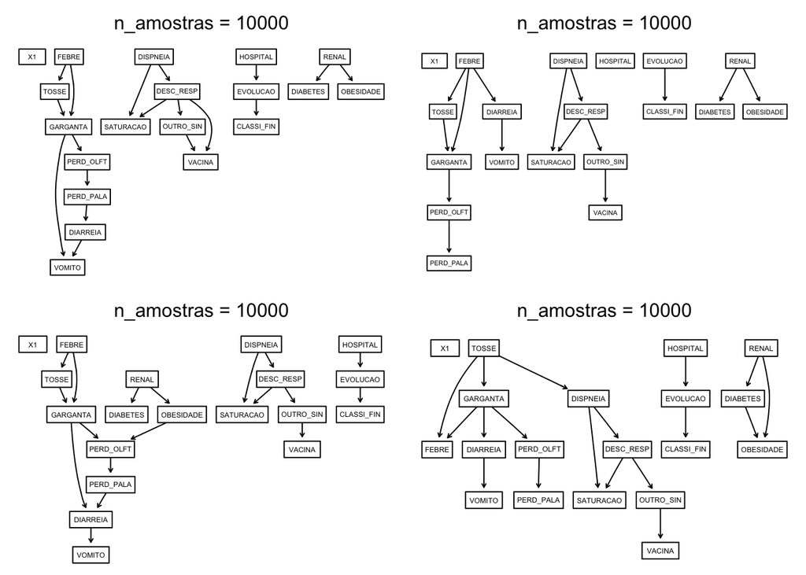

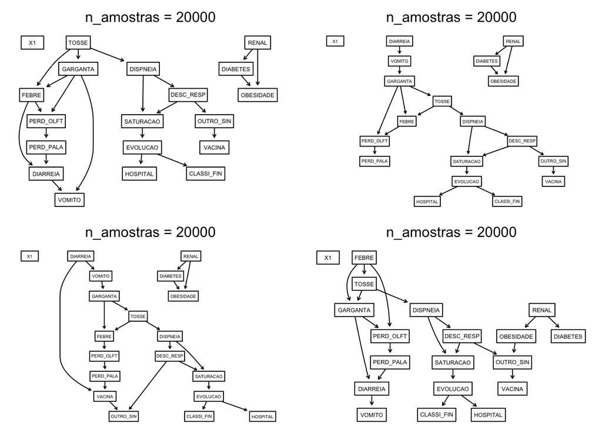

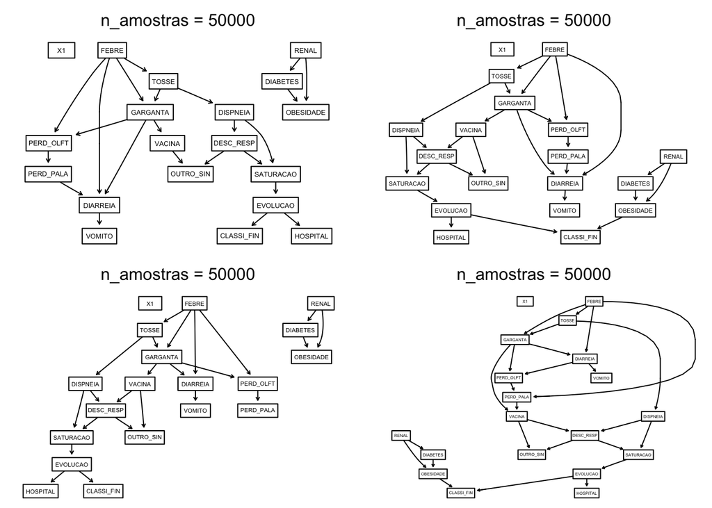

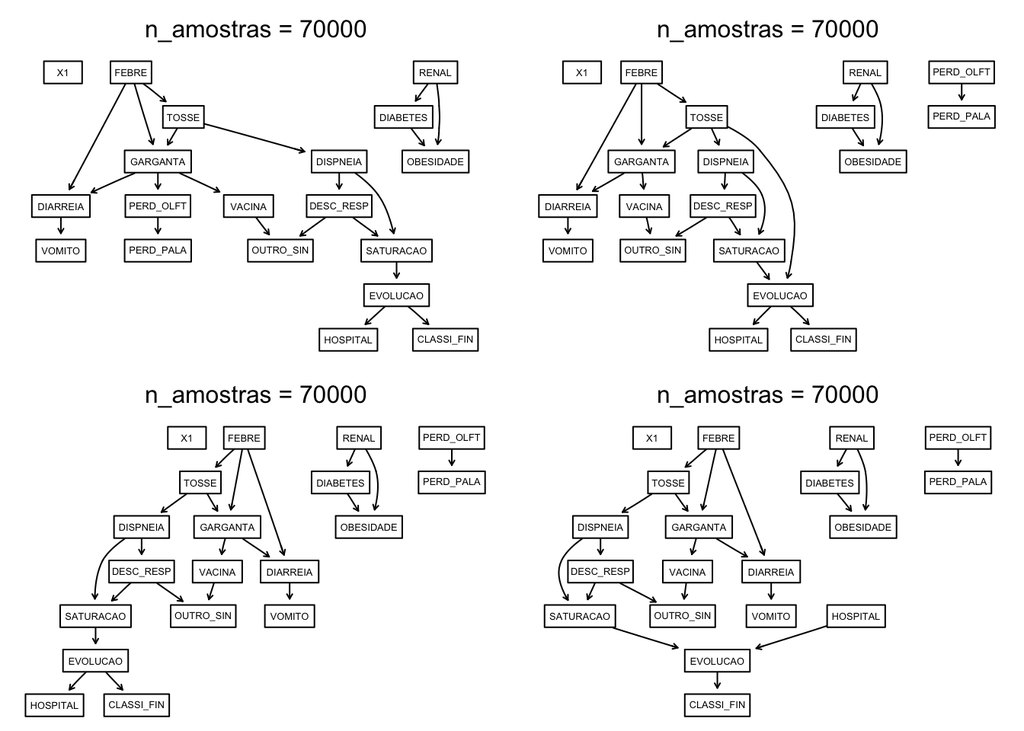

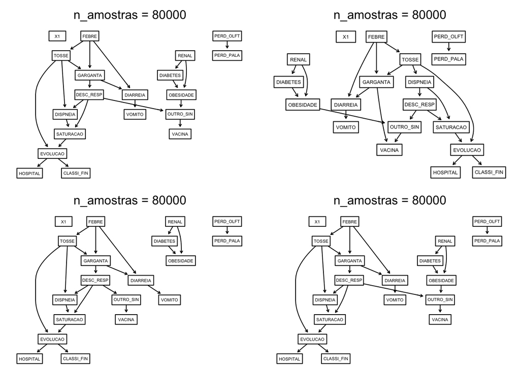

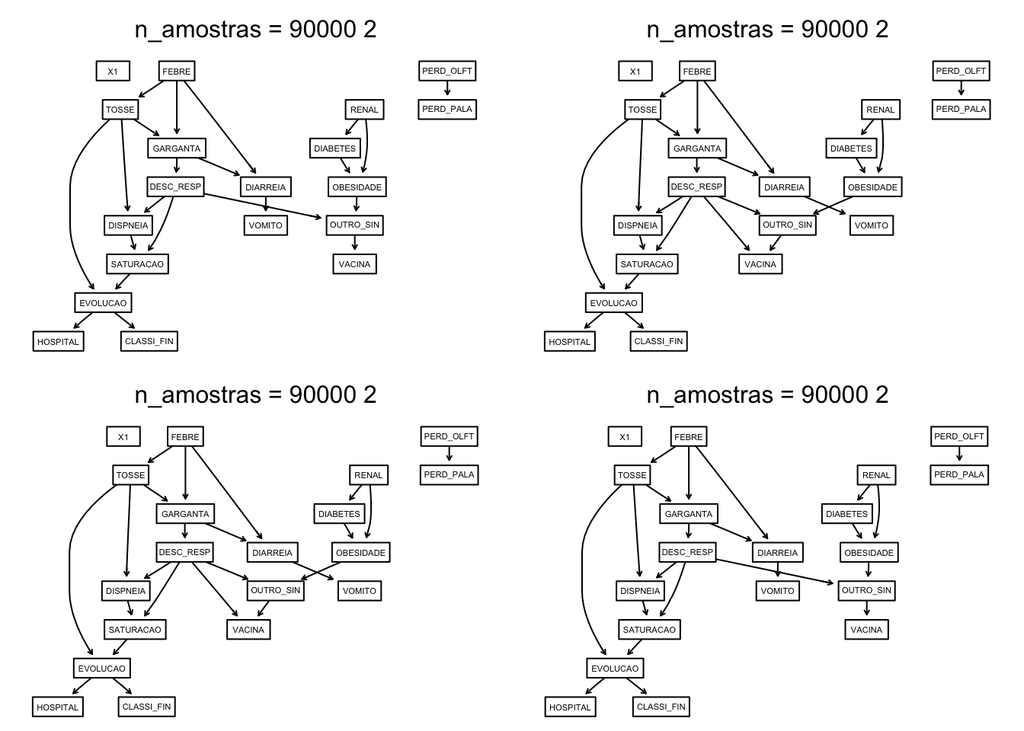

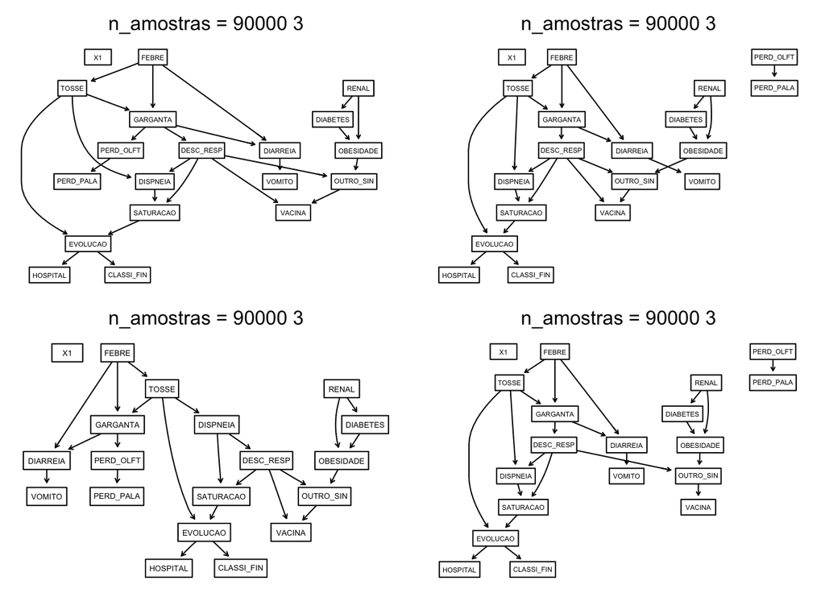

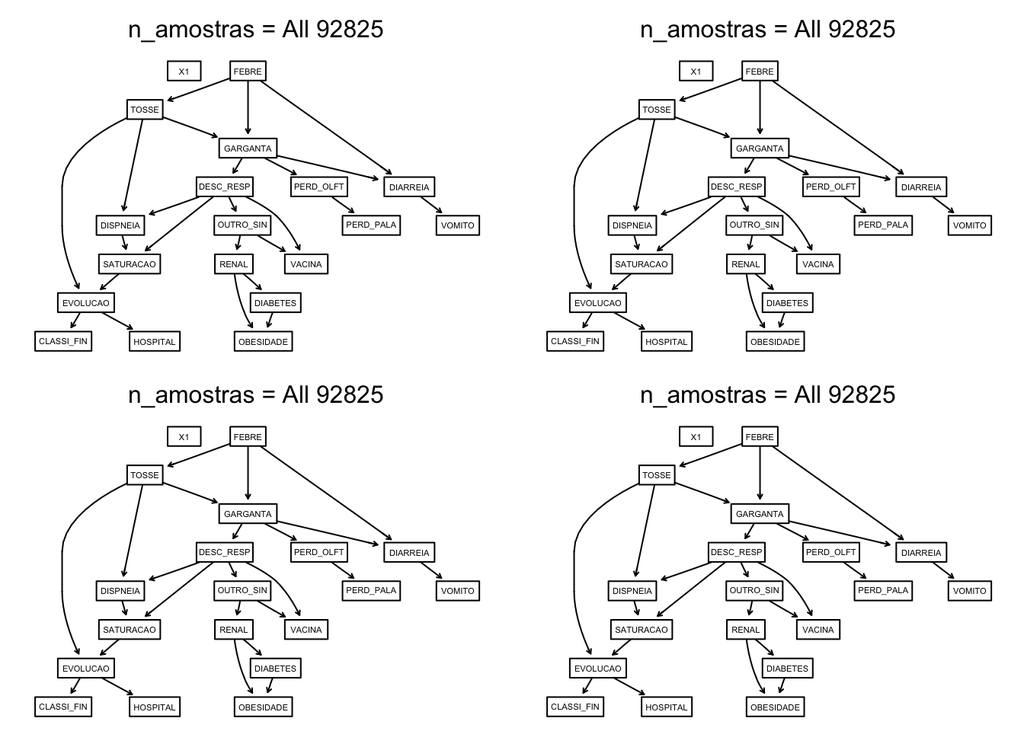

```r
suppressPackageStartupMessages(expr = library(tidyverse))
suppressPackageStartupMessages(expr = library(bnlearn))
suppressPackageStartupMessages(expr = library(bnstruct))
suppressPackageStartupMessages(expr = library(readr))
suppressPackageStartupMessages(expr = library(Rgraphviz))
suppressPackageStartupMessages(expr = library(Rmpfr))
```

# Vacinados *versus* não vacinados

## Vacinados

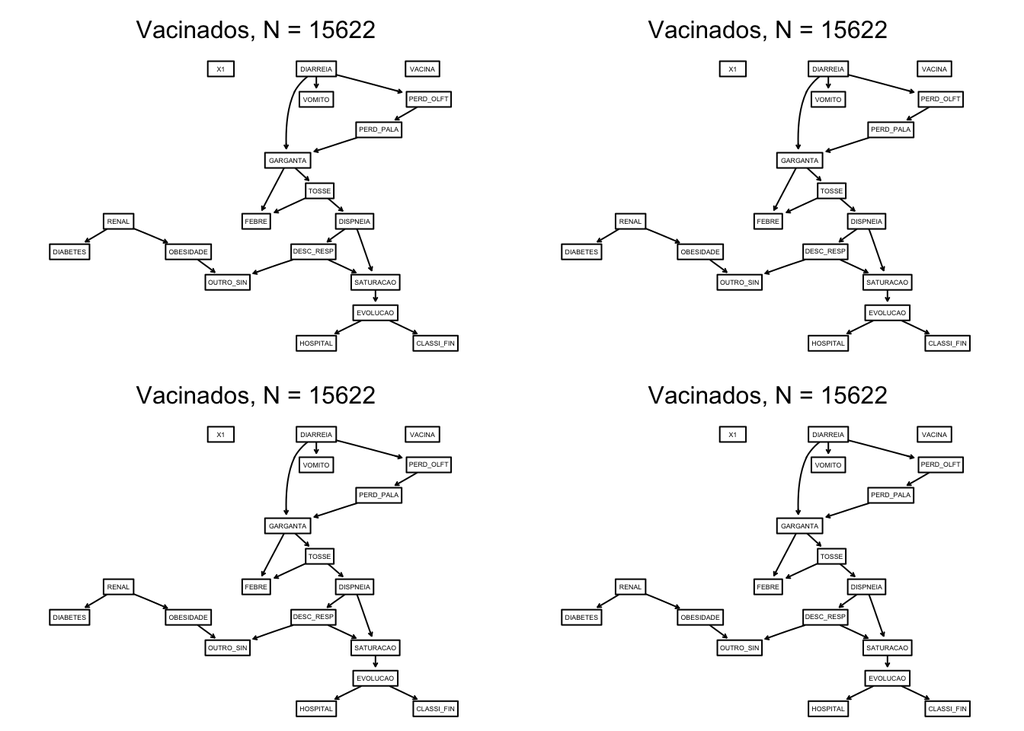

## Não Vacinados

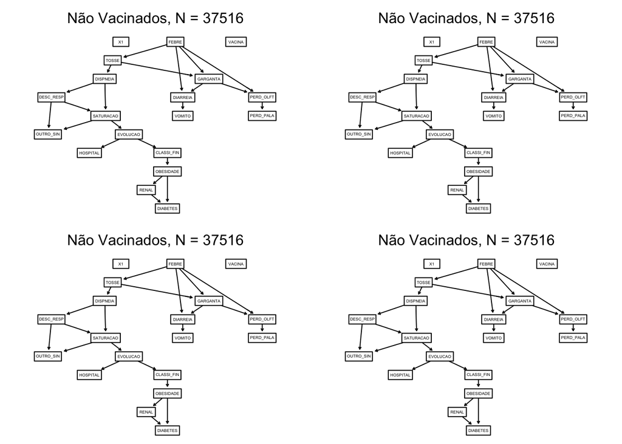

# Agrupamento por **Classificação final** dos casos

```r
# 1 - SRAG porinfluenza
# 2 - SRAG por outro virus respiratorio
# 3 - SRAG por outro agente etiologico,qual:
# 4 - SRAG nao especificado
# 5 - SRAG por COVID-19
```

```r
srag.covid <- dados_clinicos_no_na %>% filter (CLASSI_FIN == 5)
srag.nao.covid <- dados_clinicos_no_na %>% filter (CLASSI_FIN != 5)

# Dados COVID Positivos
glimpse(srag.covid)
```

```
## Rows: 74,127
## Columns: 19
## $ X1         <dbl> 2, 7, 9, 21, 26, 29, 34, 36, 39, 42, 45, 49, 56, 58, 64, 69…
## $ FEBRE      <fct> 1, 2, 2, 2, 2, 1, 2, 1, 1, 1, 1, 2, 1, 2, 1, 2, 2, 1, 1, 1,…
## $ TOSSE      <fct> 1, 1, 2, 2, 2, 2, 2, 2, 1, 2, 1, 1, 2, 1, 1, 2, 2, 1, 2, 2,…
## $ GARGANTA   <fct> 2, 2, 2, 2, 2, 2, 2, 2, 2, 2, 2, 1, 2, 1, 2, 2, 2, 1, 2, 2,…
## $ DISPNEIA   <fct> 1, 1, 1, 2, 2, 1, 2, 2, 2, 2, 1, 1, 1, 1, 2, 1, 2, 1, 2, 1,…
## $ DESC_RESP  <fct> 1, 1, 1, 2, 2, 2, 2, 2, 2, 1, 1, 1, 2, 1, 1, 2, 2, 1, 2, 1,…
## $ SATURACAO  <fct> 2, 1, 1, 1, 2, 2, 2, 2, 2, 1, 2, 2, 1, 1, 1, 1, 2, 2, 2, 2,…
## $ DIARREIA   <fct> 2, 2, 2, 1, 2, 2, 2, 2, 1, 2, 2, 2, 2, 1, 1, 2, 2, 1, 1, 2,…
## $ VOMITO     <fct> 2, 2, 2, 1, 2, 2, 2, 2, 2, 2, 2, 2, 2, 2, 2, 2, 2, 2, 2, 2,…
## $ OUTRO_SIN  <fct> 2, 2, 2, 1, 1, 2, 1, 2, 1, 2, 2, 2, 1, 2, 1, 1, 1, 2, 1, 2,…
## $ HOSPITAL   <fct> 1, 1, 1, 1, 1, 1, 1, 1, 1, 1, 1, 1, 1, 1, 1, 1, 1, 1, 1, 1,…
## $ EVOLUCAO   <fct> 1, 1, 2, 1, 1, 1, 2, 1, 2, 2, 1, 2, 1, 2, 2, 2, 1, 1, 1, 2,…
## $ RENAL      <fct> 1, 2, 2, 2, 2, 1, 2, 1, 2, 2, 2, 1, 2, 2, 2, 2, 2, 2, 2, 2,…
## $ DIABETES   <fct> 1, 1, 2, 1, 2, 1, 2, 2, 2, 2, 2, 1, 1, 1, 1, 1, 1, 1, 2, 2,…
## $ OBESIDADE  <fct> 2, 2, 2, 2, 2, 2, 2, 2, 2, 2, 2, 2, 2, 1, 2, 2, 2, 1, 2, 2,…
## $ PERD_OLFT  <fct> 2, 2, 2, 2, 2, 2, 2, 2, 2, 2, 2, 2, 2, 2, 2, 2, 2, 1, 2, 2,…
## $ PERD_PALA  <fct> 2, 2, 2, 2, 2, 2, 2, 2, 2, 2, 2, 2, 2, 2, 2, 2, 2, 2, 2, 2,…
## $ VACINA     <fct> 9, 9, 9, 9, 9, 9, 9, 1, 1, 2, 2, 1, 2, 2, 9, 9, 2, 1, 9, 2,…
## $ CLASSI_FIN <fct> 5, 5, 5, 5, 5, 5, 5, 5, 5, 5, 5, 5, 5, 5, 5, 5, 5, 5, 5, 5,…
```

```r
#
#
# Dados Covid Negativos
glimpse(srag.nao.covid)
```

```
## Rows: 18,698
## Columns: 19
## $ X1         <dbl> 4, 8, 20, 25, 27, 28, 31, 32, 38, 40, 51, 59, 70, 72, 83, 1…
## $ FEBRE      <fct> 1, 1, 2, 2, 2, 2, 1, 2, 1, 2, 9, 2, 1, 2, 2, 2, 1, 1, 2, 2,…
## $ TOSSE      <fct> 1, 1, 2, 2, 2, 2, 2, 1, 1, 2, 9, 1, 1, 1, 2, 2, 1, 1, 2, 1,…
## $ GARGANTA   <fct> 2, 1, 2, 2, 2, 2, 2, 2, 2, 2, 9, 2, 2, 2, 2, 2, 2, 2, 2, 2,…
## $ DISPNEIA   <fct> 2, 1, 1, 2, 1, 1, 2, 2, 1, 1, 1, 2, 1, 2, 2, 1, 1, 1, 2, 2,…
## $ DESC_RESP  <fct> 1, 1, 1, 2, 1, 1, 2, 2, 1, 1, 1, 2, 1, 2, 2, 1, 2, 1, 2, 2,…
## $ SATURACAO  <fct> 1, 1, 1, 2, 1, 1, 1, 1, 1, 1, 1, 1, 1, 1, 2, 1, 2, 1, 2, 2,…
## $ DIARREIA   <fct> 2, 2, 2, 2, 2, 2, 2, 1, 2, 2, 9, 2, 2, 1, 1, 2, 2, 2, 2, 2,…
## $ VOMITO     <fct> 2, 2, 2, 1, 2, 2, 2, 1, 2, 2, 9, 2, 2, 2, 1, 2, 2, 2, 2, 2,…
## $ OUTRO_SIN  <fct> 1, 1, 1, 1, 2, 2, 2, 2, 2, 1, 9, 2, 2, 2, 2, 2, 1, 2, 2, 2,…
## $ HOSPITAL   <fct> 1, 1, 1, 1, 1, 1, 1, 1, 1, 1, 1, 1, 1, 1, 1, 1, 1, 1, 1, 1,…
## $ EVOLUCAO   <fct> 1, 1, 1, 1, 1, 3, 1, 1, 1, 2, 3, 1, 2, 1, 2, 2, 1, 1, 3, 2,…
## $ RENAL      <fct> 2, 2, 2, 2, 2, 2, 2, 2, 2, 2, 2, 2, 2, 2, 2, 9, 2, 2, 1, 2,…
## $ DIABETES   <fct> 1, 2, 2, 1, 2, 1, 2, 2, 2, 2, 1, 2, 2, 1, 2, 9, 2, 2, 2, 2,…
## $ OBESIDADE  <fct> 2, 2, 2, 2, 2, 2, 2, 2, 2, 2, 2, 2, 2, 2, 2, 9, 2, 2, 2, 2,…
## $ PERD_OLFT  <fct> 2, 2, 2, 2, 2, 2, 2, 2, 2, 2, 9, 2, 2, 2, 2, 2, 2, 2, 9, 2,…
## $ PERD_PALA  <fct> 2, 2, 2, 2, 2, 2, 2, 2, 2, 2, 9, 2, 2, 2, 2, 2, 2, 2, 9, 2,…
## $ VACINA     <fct> 2, 2, 9, 9, 1, 2, 2, 9, 1, 2, 2, 2, 9, 9, 9, 2, 1, 1, 9, 9,…
## $ CLASSI_FIN <fct> 4, 4, 4, 4, 4, 4, 4, 4, 4, 4, 4, 4, 4, 4, 4, 4, 4, 4, 4, 4,…
```

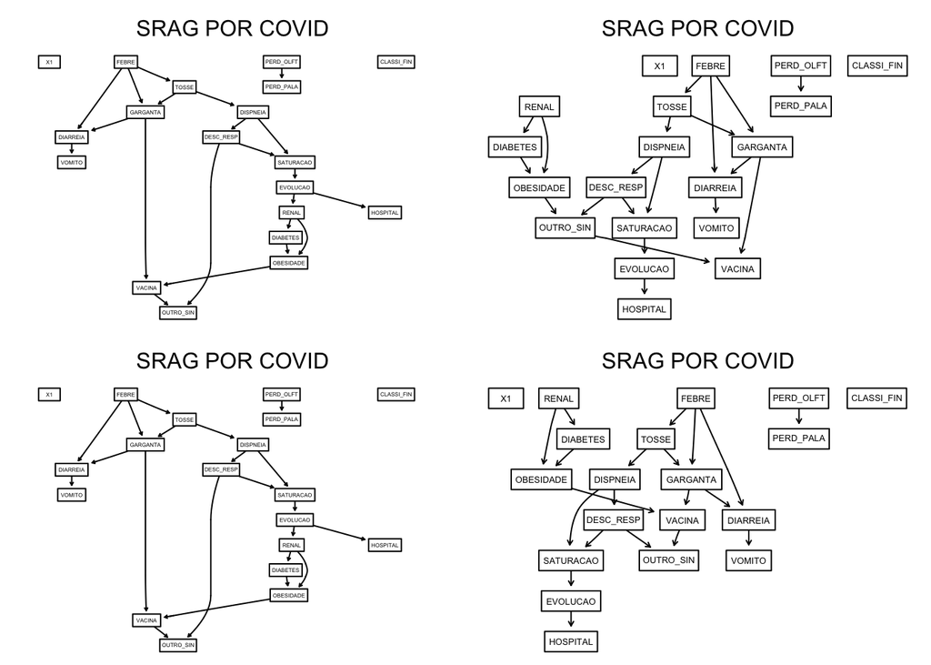

```r
#
bn.covid.1 <- mmhc(sample_frac(tbl = srag.covid, size = .9, replace = FALSE))
bn.covid.2 <- mmhc(sample_frac(tbl = srag.covid, size = .9, replace = FALSE))
bn.covid.3 <- mmhc(sample_frac(tbl = srag.covid, size = .9, replace = FALSE))
bn.covid.4 <- mmhc(sample_frac(tbl = srag.covid, size = .9, replace = FALSE))
par(mfrow=c(2,2))
graphviz.plot(bn.covid.1, main="SRAG POR COVID", shape="rectangle")
graphviz.plot(bn.covid.2, main="SRAG POR COVID", shape="rectangle")
graphviz.plot(bn.covid.3, main="SRAG POR COVID", shape="rectangle")
graphviz.plot(bn.covid.4, main="SRAG POR COVID", shape="rectangle")
```

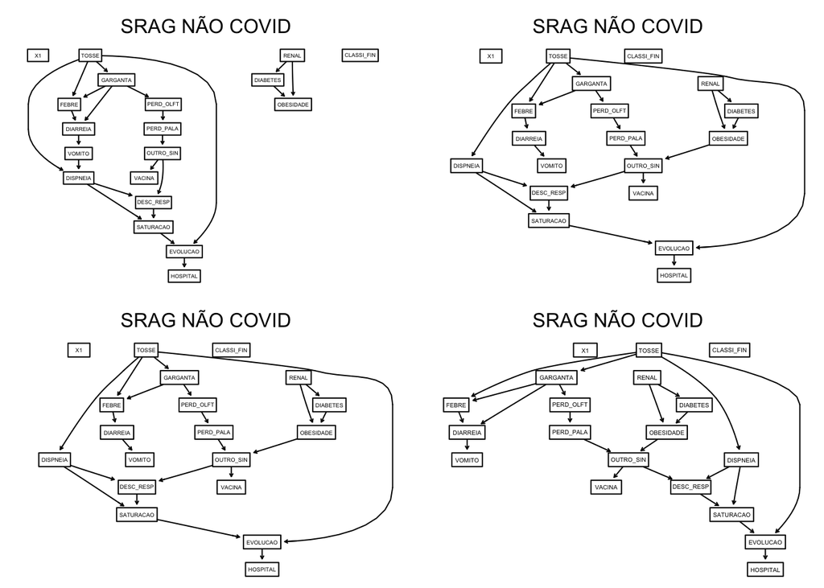

```r
#
bn.nao.covid.1 <- mmhc(sample_frac(tbl = srag.nao.covid, size = .9, replace = FALSE))
bn.nao.covid.2 <- mmhc(sample_frac(tbl = srag.nao.covid, size = .9, replace = FALSE))
bn.nao.covid.3 <- mmhc(sample_frac(tbl = srag.nao.covid, size = .9, replace = FALSE))
bn.nao.covid.4 <- mmhc(sample_frac(tbl = srag.nao.covid, size = .9, replace = FALSE))
par(mfrow=c(2,2))
graphviz.plot(bn.nao.covid.1, main="SRAG NÃO COVID", shape="rectangle")
graphviz.plot(bn.nao.covid.2, main="SRAG NÃO COVID", shape="rectangle")
graphviz.plot(bn.nao.covid.3, main="SRAG NÃO COVID", shape="rectangle")
graphviz.plot(bn.nao.covid.4, main="SRAG NÃO COVID", shape="rectangle")
```